# Analysis of longitudinal data

Finally, let’s see if there is an interaction between treatment and time, that should be taken into account.

```r
#Creating a random intercept and random slope model with the interaction
BPRS_ref2 <- lmer(bprs ~ week * treatment + (week | subject), data = BPRSL, REML = FALSE)

#Summary of the model
summary(BPRS_ref2)
```

```
## Linear mixed model fit by maximum likelihood  ['lmerMod']
## Formula: bprs ~ week * treatment + (week | subject)
##    Data: BPRSL
##
##      AIC      BIC   logLik deviance df.resid
##   2744.3   2775.4  -1364.1   2728.3      352
##
## Scaled residuals:
##     Min      1Q  Median      3Q     Max
## -3.0512 -0.6271 -0.0768  0.5288  3.9260
##
## Random effects:
##  Groups   Name        Variance Std.Dev. Corr
##  subject  (Intercept) 64.9964  8.0620
##           week         0.9687  0.9842   -0.51
##  Residual             96.4707  9.8220
## Number of obs: 360, groups:  subject, 20
##
## Fixed effects:
##                 Estimate Std. Error t value
## (Intercept)      47.8856     2.2521  21.262
## week             -2.6283     0.3589  -7.323
## treatment2       -2.2911     1.9090  -1.200
## week:treatment2   0.7158     0.4010   1.785
##
## Correlation of Fixed Effects:
##             (Intr) week   trtmn2
## week        -0.650
## treatment2  -0.424  0.469
## wek:trtmnt2  0.356 -0.559 -0.840
```

```r
#ANOVA test on this and the best model so far
anova(BPRS_ref2, BPRS_ref1)
```

```
## Data: BPRSL
## Models:
## BPRS_ref1: bprs ~ week + treatment + (week | subject)
## BPRS_ref2: bprs ~ week * treatment + (week | subject)
##           npar    AIC    BIC  logLik deviance  Chisq Df Pr(>Chisq)
## BPRS_ref1    7 2745.4 2772.6 -1365.7   2731.4
## BPRS_ref2    8 2744.3 2775.4 -1364.1   2728.3 3.1712  1    0.07495 .
## ---
## Signif. codes:  0 '***' 0.001 '**' 0.01 '*' 0.05 '.' 0.1 ' ' 1
```

As the last thing with this data set, I will plot the fitted values of BPRS.

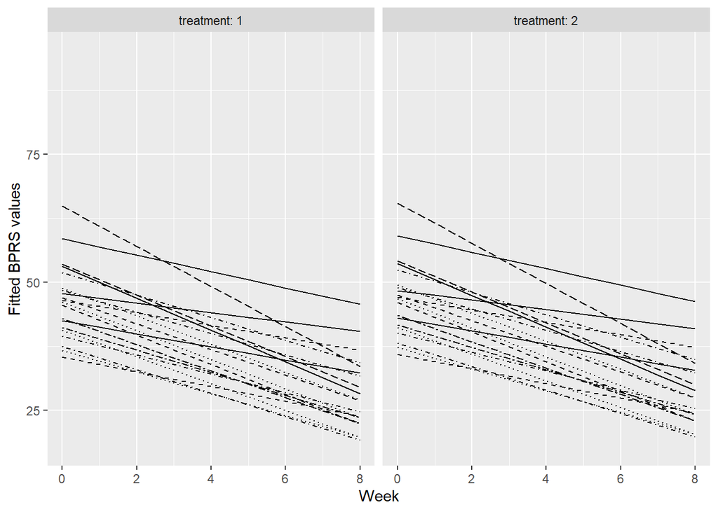

```r
#Creating a vector of the fitted values
FittedBPRS <- fitted(BPRS_ref1)

# Create a new column fitted to BPRSL
BPRSL <- mutate(BPRSL, fitted = FittedBPRS)

#Drawing the plot of BPRSL, with the Fitted values of bprs
ggplot(BPRSL, aes(x = week, y = fitted, linetype = subject)) +
  geom_line() +
  scale_linetype_manual(values = rep(1:10, times=4)) +
  facet_grid(. ~ treatment, labeller = label_both) +
  theme(legend.position = "none") +
  scale_y_continuous(name = "Fitted BPRS values", limits = c(min(BPRSL$bprs), max(BPRSL$bprs))) +
  scale_x_continuous(name="Week")
```

The BPRS values go down over time, indicating the study subjects have less/lighter psychiatric symptoms than in the beginning of the study.

Now we compare the BPRS values (real observations) with fitted values side by side. The model fitted the values quite good.

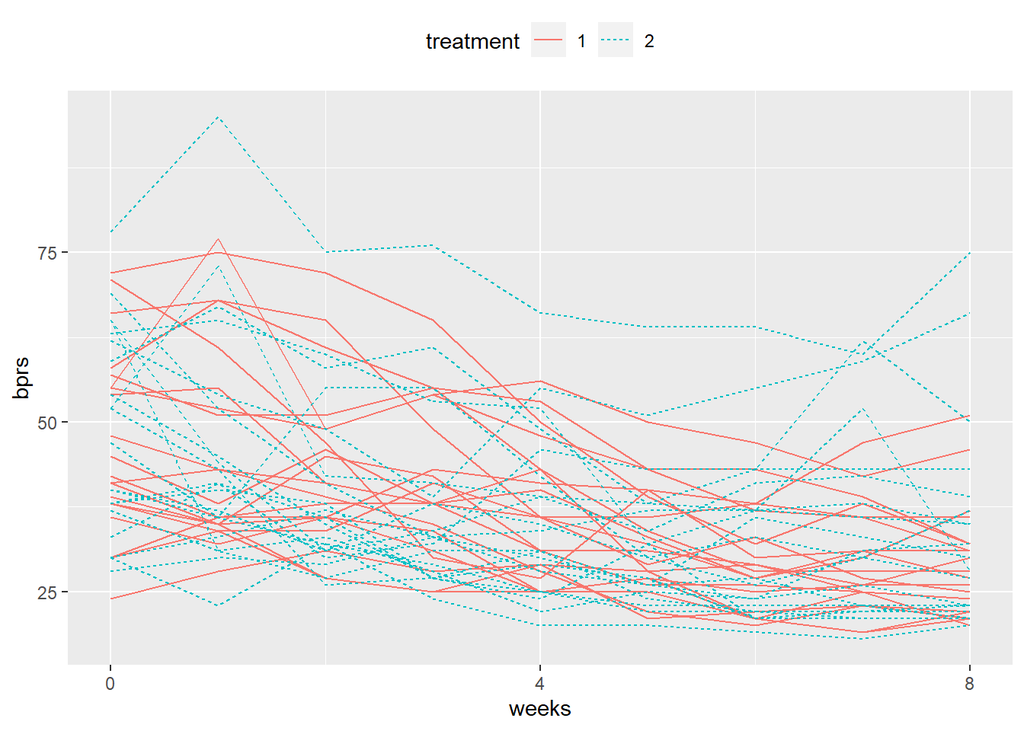

```r
plot1
```

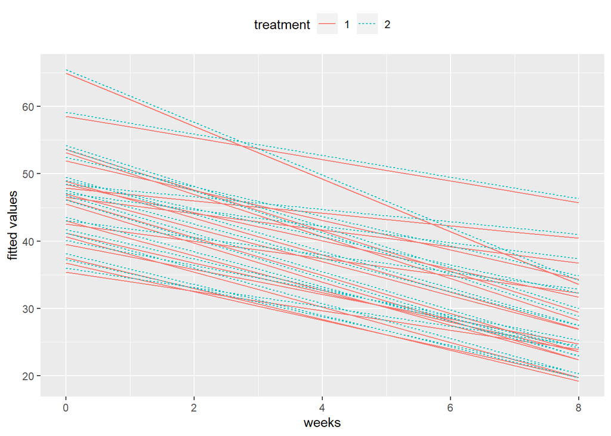

```r
plot2 <- ggplot(BPRSL, aes(x = week, y = fitted, group = interaction(subject, treatment))) +
        geom_line(aes(linetype = treatment, color=treatment)) +
        scale_x_continuous(name = "weeks", breaks = seq(0, 8, by=2)) +
        scale_y_continuous(name = "fitted values") +
        theme(legend.position = "top")

plot2
```